# Module 6: Data Visualization I

## Bivariate (two variables) display

What if we want to visualize the relationship between 2 variables? This is very common in whatever data analysis project we engage with.

The most basic plot for a bivariate display is a scatterplot. Scatterplots are used to show relationships between two continuous variables. Let’s examine the relationship between MTageopp and MTcomopp. In other words, we are examining relationship between the perceived agentic opportunities and the perceived communal opportunities for a male leader with a trustworthy face.

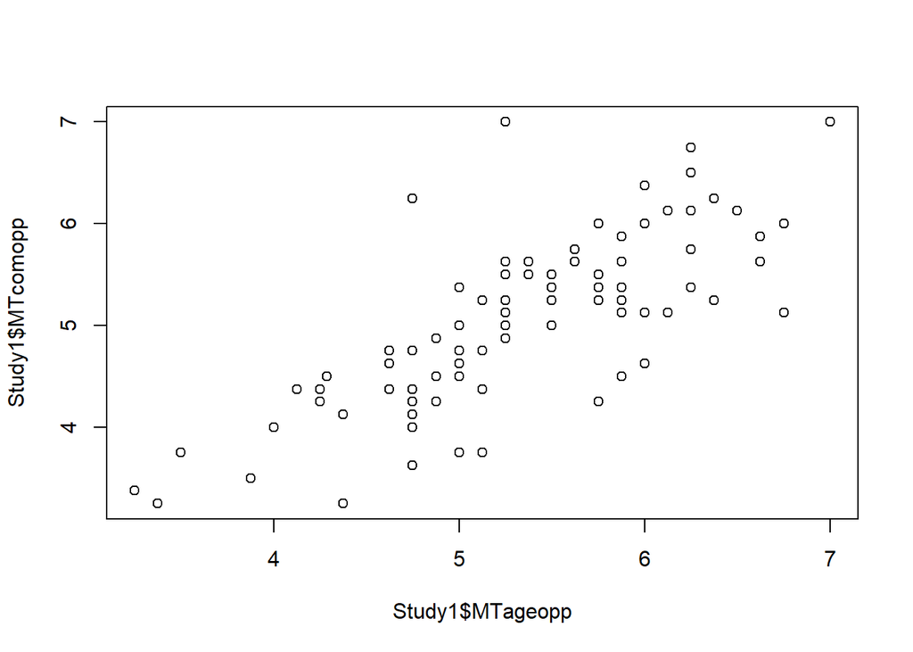

```r
plot(x=Study1$MTageopp, y=Study1$MTcomopp)
```

As usual, this is a rough first draft of a visualization. Let’s add in the titles.

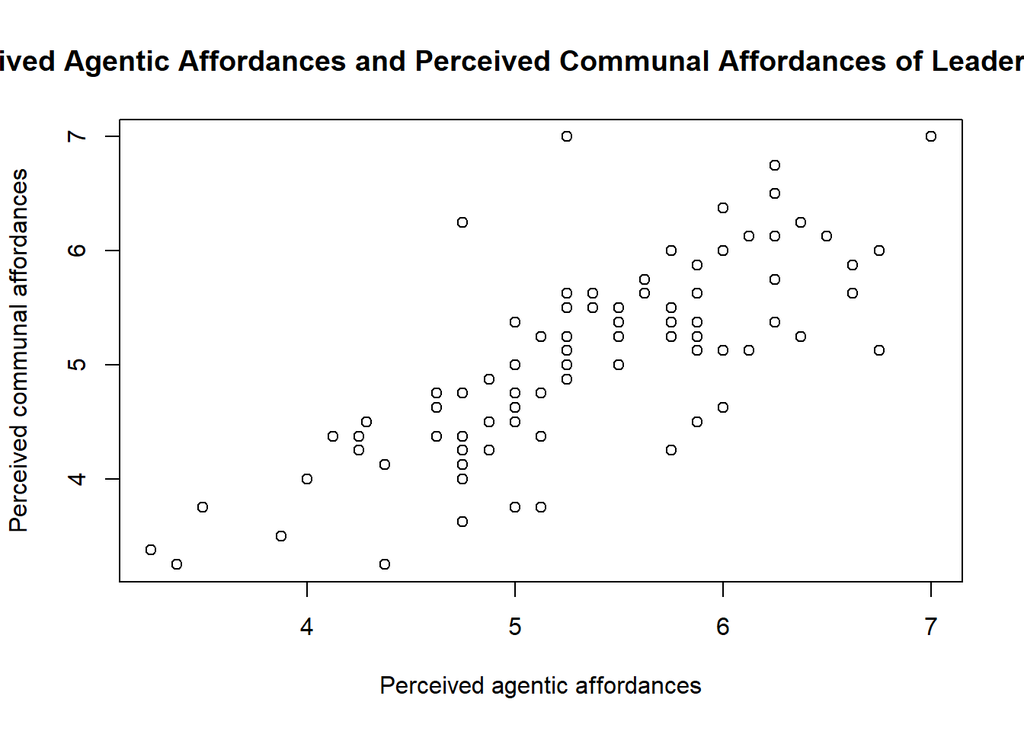

```r
plot(x=Study1$MTageopp, y=Study1$MTcomopp, xlab = "Perceived agentic affordances", ylab="Perceived communal affordances",
     main="Scatterplot between Perceived Agentic Affordances and Perceived Communal Affordances of Leaders with Male Trustworthy Faces")
```

Finally, aesthetic things. You can change the color of the dots using “col” and the shape of the dots using “pch”. Play around and find out.

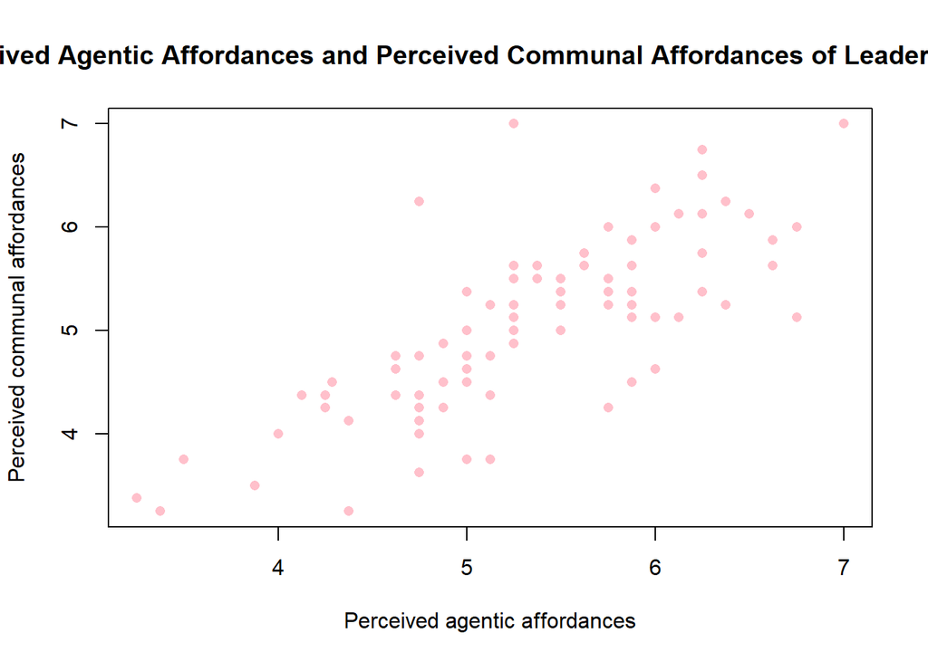

```r
plot(x=Study1$MTageopp, y=Study1$MTcomopp, xlab = "Perceived agentic affordances", ylab="Perceived communal affordances",
     main="Scatterplot between Perceived Agentic Affordances and Perceived Communal Affordances of Leaders with Male Trustworthy Faces",
     pch=16, col='pink')
```

```r
#yes, pink is my favorite color.
```

What happens if our x variable is not a continuous variable? Well, scatterplots start to look a bit strange. In this case, we would use a Box-and-whisker plot to show a relationship between a continuous y variable (dependent variable) and a categorical x variable (independent variable).

Let’s try to see how ratings of perceived agentic opportunities offered by leaders with male trusthworthy faces (MTageopp) differ by participants’ gender (pGender).

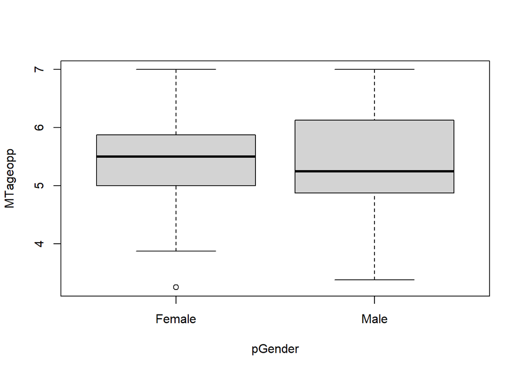

```r
boxplot(MTageopp~pGender, data=Study1)
```

Not so different across participants’ gender, isn’t it? We also see an outlier for one of the female participants as well (the dot). As usual, let’s add titles to this rough visualization.

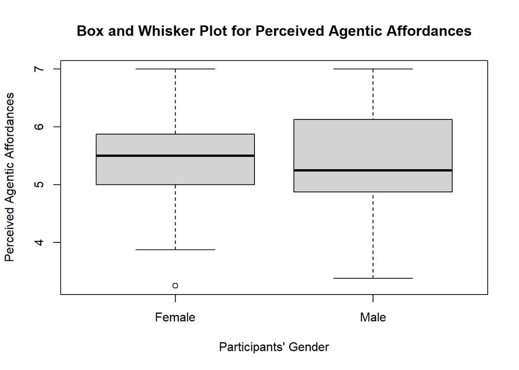

```r
boxplot(MTageopp~pGender, data=Study1, xlab = "Participants' Gender",
        ylab="Perceived Agentic Affordances", main="Box and Whisker Plot for Perceived Agentic Affordances")
```

Better. Finally, let’s consider some aesthetic options. We can change the color using “col” and the border surrounding the plot using “border” (I know, such creative names).

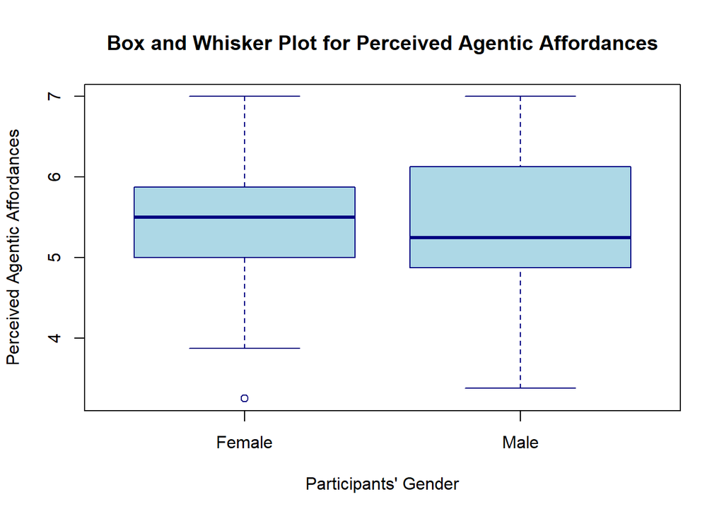

```r
boxplot(MTageopp~pGender, data=Study1, xlab = "Participants' Gender",
        ylab="Perceived Agentic Affordances", main="Box and Whisker Plot for Perceived Agentic Affordances", col="lightblue", border = "navy")
```

Look at that!

## Practice makes perfect

Download the data to Study 2 in the same project. Their datasets maybe downloaded [here](https://osf.io/tdspx/).

1, Make a density plot and a histogram for the following variables:

MD_AgeAff

MT_AgeAff

FD_AgeAff

FT_AgeAff

MD_ComAff

MT_ComAff

FD_ComAff

FT_ComAff

2, Create a barplot for the following variables:

age

pgender

race

3, Create a scatterplot to visualize the relationship between these variables:

MD_AgeAff and MD_ComAff

MT_AgeAff and MT_ComAff

FD_AgeAff and FD_ComAff

FT_AgeAff and FT_ComAff

4, Create a Box and Whisker Plot to visualize the distribution of the MD_AgeAff variable across participants’ race (“race” variable)

## Concluding words

In this module, you learned how to visualize your data using the commands in base R. As you can see, they are pretty straightforward and the resulting visualizations are not too bad. In the next module, we will learn how to create beautiful visualizations using ggplot2 (Tidyverse). Get excited.

## References

Hehman, E., & Xie, S. Y. (2021). Doing Better Data Visualization. Advances in Methods and Practices in Psychological Science, 4(4), 25152459211045336. https://doi.org/10.1177/25152459211045334

Joshi, M. P., Lloyd, E. P., Diekman, A. B., & Hugenberg, K. (2023). In the Face of Opportunities: Facial Structures of Scientists Shape Expectations of STEM Environments. Personality & Social Psychology Bulletin, 49(5), 673–691. https://doi.org/10.1177/01461672221077801